# R Lab 4 Exercise

Prof. Amanda D. Perez, PhD

# Correlation

```r
library(tidyverse)
library(psych)
library(scales)
library(forcats)
library(viridis)
```

For this section you will be using Billboard music data from TidyTuesday. See https://github.com/rfordatascience/tidytuesday/tree/master/data/2021/2021-09-14 for more detailed information about the dataset.

```r
set.seed(8765)
billboard <- readr::read_csv('https://raw.githubusercontent.com/rfordatascience/tidytuesday/master/data/2021/2021-09-14/audio_features.csv') %>% sample_n(5000)
glimpse(billboard)
```

```
## Rows: 5,000
## Columns: 22
## $ song_id                   <chr> "Magic ManHeart", "Light Up The WorldGlee Ca…
## $ performer                 <chr> "Heart", "Glee Cast", "Phil Vassar", "Cathy …
## $ song                      <chr> "Magic Man", "Light Up The World", "Last Day…
## $ spotify_genre             <chr> "['folk-pop', 'indie folk', 'indie pop', 'ne…
## $ spotify_track_id          <chr> "4sUlsy0tPv9n5nqrqeA0lE", "1Et2wMhDPqbu5y4sG…
## $ spotify_track_preview_url <chr> NA, "https://p.scdn.co/mp3-preview/b009108a2…
## $ spotify_track_duration_ms <dbl> 328360, 223653, 234306, NA, 46253, NA, 16062…
## $ spotify_track_explicit    <lgl> FALSE, FALSE, FALSE, NA, FALSE, NA, FALSE, F…
## $ spotify_track_album       <chr> "Dreamboat Annie", "Glee: The Musi", "Totall…
## $ danceability              <dbl> 0.435, 0.689, 0.557, NA, 0.632, NA, 0.615, 0…
## $ energy                    <dbl> 0.444, 0.796, 0.549, NA, 0.323, NA, 0.479, 0…
## $ key                       <dbl> 7, 10, 0, NA, 10, NA, 7, 2, 8, 9, 5, 2, 5, 9…
## $ loudness                  <dbl> -12.816, -5.472, -6.674, NA, -14.042, NA, -8…
## $ mode                      <dbl> 0, 1, 1, NA, 0, NA, 1, 1, 0, 0, 1, 0, 1, 0, …
## $ speechiness               <dbl> 0.0336, 0.0406, 0.0246, NA, 0.9510, NA, 0.06…
## $ acousticness              <dbl> 0.159000, 0.000599, 0.272000, NA, 0.811000, …
## $ instrumentalness          <dbl> 7.05e-04, 0.00e+00, 0.00e+00, NA, 0.00e+00, …
## $ liveness                  <dbl> 0.4570, 0.1200, 0.1090, NA, 0.1020, NA, 0.27…
## $ valence                   <dbl> 0.734, 0.857, 0.268, NA, 0.769, NA, 0.788, 0…
## $ tempo                     <dbl> 103.818, 118.029, 139.945, NA, 171.053, NA, …
## $ time_signature            <dbl> 4, 4, 3, NA, 4, NA, 4, 3, 4, 4, 4, 4, 4, 4, …
## $ spotify_track_popularity  <dbl> 59, 48, 30, NA, 18, NA, 45, 14, 63, 63, 51, …
```

## Exercise 1 -

Use the `corr.test()` function to run a correlation. Select any two numeric variables of interest for your correlation. Interpret the output in terms of significance and direction.

```r
#code goes here
```

## Exercise 2 -

Create a ggplot scatterplot visualization of the two variables you selected for the correlation. Add a geom_smooth regression “lm” line to the plot. Interpret what you see. Make sure you clean up the labels and add a theme.

```r
#code goes here
```

## Exercise 3 -

Use the `corr.test()` function to run a different correlation. Select any two numeric variables of interest (different from exercise 1) for your correlation. Interpret the output in terms of significance and direction.

```r
#code goes here
```

## Exercise 4 -

Create a ggplot scatterplot visualization of the two variables you selected for the previous correlation. Add a geom_smooth regression “lm” line to the plot. Interpret what you see. Make sure you clean up the labels and add a theme.

```r
#code goes here
```

## Exercise 5 -

Below I have created `billboard_numeric`. Your goal now is to run a p value matrix using the custom `cor.mtest` function (and save it into an object called `b_pvalues`).

```r
#Run this chunk as-is and do not make any changes
cor.mtest <- function(mat, ...) {
    mat <- as.matrix(mat)
    n <- ncol(mat)
    p.mat<- matrix(NA, n, n)
    diag(p.mat) <- 0
    for (i in 1:(n - 1)) {
        for (j in (i + 1):n) {
            tmp <- cor.test(mat[, i], mat[, j], ...)
            p.mat[i, j] <- p.mat[j, i] <- tmp$p.value
        }
    }
  colnames(p.mat) <- rownames(p.mat) <- colnames(mat)
  p.mat
}
```

```r
billboard_numeric <- billboard %>%
  select(spotify_track_duration_ms, danceability, energy, loudness,
         acousticness, liveness, valence, tempo, spotify_track_popularity) %>%
  na.omit() %>%
  cor()

#code goes here
```

## Exercise 6 -

Your final exercise in this correlation exercise is to edit the below correlation matrix plot using the `corrplot` library.

Make sure you: 1. Set the corrgram to “upper” to display only the upper triangular of the correlation matrix 2. Hide the correlation coefficients on the principal diagonal by adding: `diag=FALSE` 3. Set `p.mat = b_pvalues`, `sig.level = 0.05`, `insig = "pch"`, `addCoef.col = "black"`, `tl.col="black"`, and `tl.srt=45`

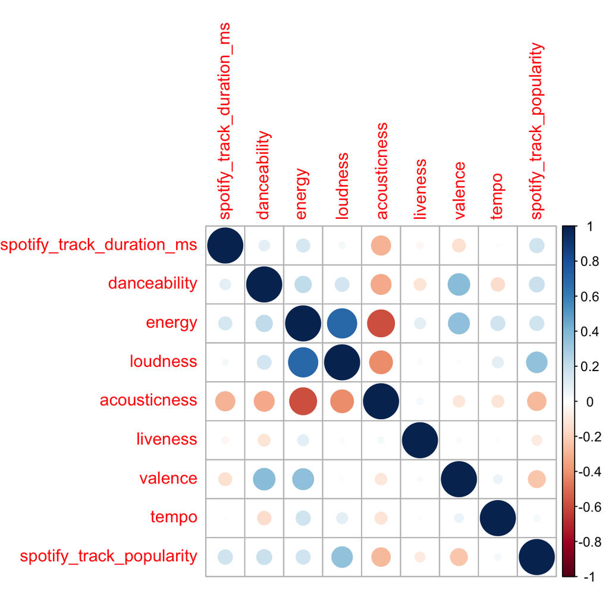

```r
library(corrplot)
corrplot(billboard_numeric)
```

# T-Tests

```r
set.seed(8765)
nurses <- readr::read_csv('https://raw.githubusercontent.com/rfordatascience/tidytuesday/master/data/2021/2021-10-05/nurses.csv')
nurses$Year <- as.factor(nurses$Year)
nurses$State <- as.factor(nurses$State)

glimpse(nurses)
```

```
## Rows: 1,242
## Columns: 22
## $ State                                             <fct> Alabama, Alaska, Ari…
## $ Year                                              <fct> 2020, 2020, 2020, 20…
## $ `Total Employed RN`                               <dbl> 48850, 6240, 55520, …
## $ `Employed Standard Error (%)`                     <dbl> 2.9, 13.0, 3.7, 4.2,…
## $ `Hourly Wage Avg`                                 <dbl> 28.96, 45.81, 38.64,…
## $ `Hourly Wage Median`                              <dbl> 28.19, 45.23, 37.98,…
## $ `Annual Salary Avg`                               <dbl> 60230, 95270, 80380,…
## $ `Annual Salary Median`                            <dbl> 58630, 94070, 79010,…
## $ `Wage/Salary standard error (%)`                  <dbl> 0.8, 1.4, 0.9, 1.4, …
## $ `Hourly 10th Percentile`                          <dbl> 20.75, 31.50, 27.66,…
## $ `Hourly 25th Percentile`                          <dbl> 23.73, 36.94, 32.58,…
## $ `Hourly 75th Percentile`                          <dbl> 33.15, 53.31, 44.67,…
## $ `Hourly 90th Percentile`                          <dbl> 38.67, 60.70, 50.14,…
## $ `Annual 10th Percentile`                          <dbl> 43150, 65530, 57530,…
## $ `Annual 25th Percentile`                          <dbl> 49360, 76830, 67760,…
## $ `Annual 75th Percentile`                          <dbl> 68960, 110890, 92920…
## $ `Annual 90th Percentile`                          <dbl> 80420, 126260, 10429…
## $ `Location Quotient`                               <dbl> 1.20, 0.98, 0.91, 1.…
## $ `Total Employed (National)_Aggregate`             <dbl> 140019790, 140019790…
## $ `Total Employed (Healthcare, National)_Aggregate` <dbl> 8632190, 8632190, 86…
## $ `Total Employed (Healthcare, State)_Aggregate`    <dbl> 128600, 17730, 17101…
## $ `Yearly Total Employed (State)_Aggregate`         <dbl> 1903210, 296300, 283…
```